# Stratigraphic Paleobiology for Event Data

## Introduction

This vignette provides an introduction to stratigraphic paleobiology applied to “*event type data*” such as location and age of specimens, and first/last occurrences of taxa.

First, let’s load the required packages:

```r
library(StratPal)
library(admtools)
```

## Modeling fossil occurrences and first/last fossil occurrences

Location and age of fossil specimens and first/last occurrences of taxa can be considered distinct events that occur at specific points in time or stratigraphic positions. Up to a few notable exceptions, the same principles apply to this “*event type data*”, so we treat them together.

We model events as *point processes*. In the `StratPal` package, we provide two functions to simulate point processes:

- `p3`, short for Poisson point process, to simulate events that occur at a constant rate
- `p3_var_rate` for variable rate Poisson point processes to simulate events that occur at variable rates (e.g. extinction events)

The usage of `p3` is straightforward:

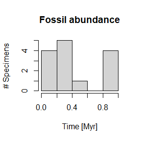

```r
# simulate fossil occurrences over one Myr with an average of 15 occurrences per Myr
p3(rate = 15, from = 0, to = 1) |>
  hist(main = "Fossil abundance",
       xlab = "Time [Myr]",
       ylab = "# Specimens")
```

Note that due to to random fluctuations, the histogram can differ a lot from the constant rate that we simulated. This effect is more pronounced for low rates.

For `p3_var_rate`, you can pass either a function that specifies the rate to `x`:

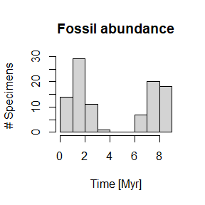

```r
# return 100 occurrences by setting n parameter
# note that negative rates (where sin < 0) are ignored
p3_var_rate(x = sin, from = 0, to = 9, n = 100) |>
  hist(xlab = "Time [Myr]",
       ylab= "# Specimens",
       main = "Fossil abundance")
```

Alternatively, you can pass it two vectors `x` and `y`. The rate is then determined by linear interpolation between these vectors. This is equivalent to using the function `approxfun(x,y, rule = 2)` as input for `x`.

[figure not shown]

```r
# decline in last occurrences from 50 to 0 over 1 Myr
p3_var_rate(x = c(0,1), y = c(50, 0), from = 0, to = 1, f_max = 50) |>
  hist(xlab = "Time [Myr]",
       main = "Last occurrences",
       ylab = "# Last occurrences")
```

Keep in mind that it is only a matter of interpretation whether the “events” produced by `p3` and `p3_var_rate` are age/timing or locations of specimens from one taxon or of first/last occurrences of multiple taxa. The conceptual framework holds for any type of event type.

**Task:** Model an “extinction event” with a background rate of 3 species disappearing per Myr, and a peak in extinction rate where the rate is 10-fold increased over an interval of 200 kyr. How distinct is the peak in the histogram, and how much do the results differ due to randomness when you run the simulation multiple times?